# ExtraaLearn Project

## Context

The EdTech industry has been surging in the past decade immensely, and according to a forecast, the Online Education market would be worth $286.62bn by 2023 with a compound annual growth rate (CAGR) of 10.26% from 2018 to 2023. The modern era of online education has enforced a lot in its growth and expansion beyond any limit. Due to having many dominant features like ease of information sharing, personalized learning experience, transparency of assessment, etc, it is now preferable to traditional education.

In the present scenario due to the Covid-19, the online education sector has witnessed rapid growth and is attracting a lot of new customers. Due to this rapid growth, many new companies have emerged in this industry. With the availability and ease of use of digital marketing resources, companies can reach out to a wider audience with their offerings. The customers who show interest in these offerings are termed as leads. There are various sources of obtaining leads for Edtech companies, like

- The customer interacts with the marketing front on social media or other online platforms.
- The customer browses the website/app and downloads the brochure
- The customer connects through emails for more information.

The company then nurtures these leads and tries to convert them to paid customers. For this, the representative from the organization connects with the lead on call or through email to share further details.

## Objective

ExtraaLearn is an initial stage startup that offers programs on cutting-edge technologies to students and professionals to help them upskill/reskill. With a large number of leads being generated on a regular basis, one of the issues faced by ExtraaLearn is to identify which of the leads are more likely to convert so that they can allocate resources accordingly. You, as a data scientist at ExtraaLearn, have been provided the leads data to:

- Analyze and build an ML model to help identify which leads are more likely to convert to paid customers,
- Find the factors driving the lead conversion process
- Create a profile of the leads which are likely to convert

## Data Description

The data contains the different attributes of leads and their interaction details with ExtraaLearn. The detailed data dictionary is given below.

**Data Dictionary**

- ID: ID of the lead
- age: Age of the lead
- current_occupation: Current occupation of the lead. Values include 'Professional','Unemployed',and 'Student'
- first_interaction: How did the lead first interacted with ExtraaLearn. Values include 'Website', 'Mobile App'
- profile_completed: What percentage of profile has been filled by the lead on the website/mobile app. Values include Low - (0-50%), Medium - (50-75%), High (75-100%)
- website_visits: How many times has a lead visited the website
- time_spent_on_website: Total time spent on the website
- page_views_per_visit: Average number of pages on the website viewed during the visits.
- last_activity: Last interaction between the lead and ExtraaLearn.
  - Email Activity: Seeking for details about program through email, Representative shared information with lead like brochure of program , etc
  - Phone Activity: Had a Phone Conversation with representative, Had conversation over SMS with representative, etc
  - Website Activity: Interacted on live chat with representative, Updated profile on website, etc
- print_media_type1: Flag indicating whether the lead had seen the ad of ExtraaLearn in the Newspaper.
- print_media_type2: Flag indicating whether the lead had seen the ad of ExtraaLearn in the Magazine.
- digital_media: Flag indicating whether the lead had seen the ad of ExtraaLearn on the digital platforms.
- educational_channels: Flag indicating whether the lead had heard about ExtraaLearn in the education channels like online forums, discussion threads, educational websites, etc.
- referral: Flag indicating whether the lead had heard about ExtraaLearn through reference.
- status: Flag indicating whether the lead was converted to a paid customer or not.

## Importing necessary libraries and data

```python
# Importing the library packages
import pandas as pd  # library used for data manipulation and analysis
import numpy as np  # library used for working with arrays
import matplotlib.pyplot as plt  # library for plots and visualizations
import seaborn as sns  # library for visualizations
sns.set()

# Suppressing warnings
import warnings
warnings.filterwarnings('ignore')

# Importing machine learning models from Scikit-Learn
from sklearn.linear_model import LogisticRegression
from sklearn.svm import SVC
from sklearn.tree import DecisionTreeClassifier
from sklearn import tree
from sklearn.ensemble import RandomForestClassifier

# Importing additional functions from Scikit-Learn
from sklearn.model_selection import train_test_split, GridSearchCV
from sklearn.preprocessing import MinMaxScaler, LabelEncoder, OneHotEncoder
from sklearn.impute import SimpleImputer

# Importing functions to generate different metric scores
from sklearn.metrics import confusion_matrix,classification_report,roc_auc_score,precision_recall_curve,roc_curve,make_scorer,recall_score
```

```python
# Loading the data set
df = pd.read_csv('ExtraaLearn.csv')
```

```python
# Copying data to another variable to avoid any changes to the original data
df_edtech = df.copy()
```

## Approach to arrive at the insights and recommendations:

1. Importing the necessary libraries
2. Reading in the dataset to get an overview
3. Conducting exploratory data analysis - a. Univariate b. Bivariate c. Answering questions about particular variables of interest
4. Pre-processsing data where required
5. Defining the performance metric and building the relevant ML models
6. Checking for assumptions
7. Comparing the models and determining which performs best
8. Choosing the best model
9. Summarising the key observations, business insights and recommendations

## Data Overview

```python
# Looking at the data-set head, first 3 observations
df.head(3)
```

|  | ID | age | current_occupation | first_interaction | profile_completed | website_visits | time_spent_on_website | page_views_per_visit | last_activity | print_media_type1 | print_media_type2 | digital_media | educational_channels | referral | status |
| --- | --- | --- | --- | --- | --- | --- | --- | --- | --- | --- | --- | --- | --- | --- | --- |
| 0 | EXT001 | 57 | Unemployed | Website | High | 7 | 1639 | 1.86 | Website Activity | Yes | No | Yes | No | No | 1 |
| 1 | EXT002 | 56 | Professional | Mobile App | Medium | 2 | 83 | 0.32 | Website Activity | No | No | No | Yes | No | 0 |
| 2 | EXT003 | 52 | Professional | Website | Medium | 3 | 330 | 0.07 | Website Activity | No | No | Yes | No | No | 0 |

```python
# Looking at the tail, last 3 observations
df.tail(3)
```

|  | ID | age | current_occupation | first_interaction | profile_completed | website_visits | time_spent_on_website | page_views_per_visit | last_activity | print_media_type1 | print_media_type2 | digital_media | educational_channels | referral | status |
| --- | --- | --- | --- | --- | --- | --- | --- | --- | --- | --- | --- | --- | --- | --- | --- |
| 4609 | EXT4610 | 58 | Professional | Website | High | 2 | 212 | 2.69 | Email Activity | No | No | No | No | No | 1 |
| 4610 | EXT4611 | 57 | Professional | Mobile App | Medium | 1 | 154 | 3.88 | Website Activity | Yes | No | No | No | No | 0 |
| 4611 | EXT4612 | 55 | Professional | Website | Medium | 4 | 2290 | 2.08 | Phone Activity | No | No | No | No | No | 0 |

```python
# Understanding the shape of the dataset
df.shape
```

```
(4612, 15)
```

```python
# Checking the data types of the columns in the dataset
df.info()
```

```
<class 'pandas.core.frame.DataFrame'>
RangeIndex: 4612 entries, 0 to 4611
Data columns (total 15 columns):
 #   Column                 Non-Null Count  Dtype
---  ------                 --------------  -----
 0   ID                     4612 non-null   object
 1   age                    4612 non-null   int64
 2   current_occupation     4612 non-null   object
 3   first_interaction      4612 non-null   object
 4   profile_completed      4612 non-null   object
 5   website_visits         4612 non-null   int64
 6   time_spent_on_website  4612 non-null   int64
 7   page_views_per_visit   4612 non-null   float64
 8   last_activity          4612 non-null   object
 9   print_media_type1      4612 non-null   object
 10  print_media_type2      4612 non-null   object
 11  digital_media          4612 non-null   object
 12  educational_channels   4612 non-null   object
 13  referral               4612 non-null   object
 14  status                 4612 non-null   int64
dtypes: float64(1), int64(4), object(10)
memory usage: 540.6+ KB
```

```python
# Confirming that there are missing values in each column
df.isna().sum()
```

```
ID                       0
age                      0
current_occupation       0
first_interaction        0
profile_completed        0
website_visits           0
time_spent_on_website    0
page_views_per_visit     0
last_activity            0
print_media_type1        0
print_media_type2        0
digital_media            0
educational_channels     0
referral                 0
status                   0
dtype: int64
```

```python
# Checking the number of unique values in each column
df.nunique()
```

```
ID                       4612
age                        46
current_occupation          3
first_interaction           2
profile_completed           3
website_visits             27
time_spent_on_website    1623
page_views_per_visit     2414
last_activity               3
print_media_type1           2
print_media_type2           2
digital_media               2
educational_channels        2
referral                    2
status                      2
dtype: int64
```

```python
# Dealing with the unique values
# Dropping ID column since it is unique and will not provide significant value in analysis
df.drop(columns='ID', inplace=True, axis=1)
```

```python
# Converting the data type of each categorical variable to 'category'
for column in cat_col:
    df[column]=df[column].astype('category')

df.info()
```

```
<class 'pandas.core.frame.DataFrame'>
RangeIndex: 4612 entries, 0 to 4611
Data columns (total 14 columns):
 #   Column                 Non-Null Count  Dtype
---  ------                 --------------  -----
 0   age                    4612 non-null   int64
 1   current_occupation     4612 non-null   category
 2   first_interaction      4612 non-null   category
 3   profile_completed      4612 non-null   category
 4   website_visits         4612 non-null   int64
 5   time_spent_on_website  4612 non-null   int64
 6   page_views_per_visit   4612 non-null   float64
 7   last_activity          4612 non-null   category
 8   print_media_type1      4612 non-null   category
 9   print_media_type2      4612 non-null   category
 10  digital_media          4612 non-null   category
 11  educational_channels   4612 non-null   category
 12  referral               4612 non-null   category
 13  status                 4612 non-null   int64
dtypes: category(9), float64(1), int64(4)
memory usage: 221.9 KB
```

## Exploratory Data Analysis (EDA) and Data Preprocessing

I will conduct EDA using the following approach:

- Viewing the statistical summaries of the dataset
- Grouping the continous and categorical variables into separate arrays
- Univariate analysis
- Bivariate analysis
- Observations and providing answers to key business questions

### Checking the statistical summary of the data.

```python
# Checking the summary statistics of the columns with continous observations
df.describe().T
```

|  | count | mean | std | min | 25% | 50% | 75% | max |
| --- | --- | --- | --- | --- | --- | --- | --- | --- |
| age | 4612.00 | 46.20 | 13.16 | 18.00 | 36.00 | 51.00 | 57.00 | 63.00 |
| website_visits | 4612.00 | 3.57 | 2.83 | 0.00 | 2.00 | 3.00 | 5.00 | 30.00 |
| time_spent_on_website | 4612.00 | 724.01 | 743.83 | 0.00 | 148.75 | 376.00 | 1336.75 | 2537.00 |
| page_views_per_visit | 4612.00 | 3.03 | 1.97 | 0.00 | 2.08 | 2.79 | 3.76 | 18.43 |
| status | 4612.00 | 0.30 | 0.46 | 0.00 | 0.00 | 0.00 | 1.00 | 1.00 |

#### Observations:

The statistical summary shows:

- The **average age of a lead is around 46 years**, the minimum and maximum are 18 and 63 respectively
- The leads **visited the website about 3,5 times** on average.
- The **average times spent on the website is 12 minutes** *(724/60)*, there is a significant difference between time spent on the website 3rd quartile value compared to the 1st and 2nd quartiles, showing that leads in the **third quartile spent at least 2,5 times more time on the website** *(1336.75000/(376.000+148.75000))*.
- There are about **3 average page views per visit**, with the **maximum being about 18**.

**Checking value summaries of the categorical data.**

```python
# Checking the summary of categorical variables
df.describe(exclude = 'number').T
```

|  | count | unique | top | freq |
| --- | --- | --- | --- | --- |
| current_occupation | 4612 | 3 | Professional | 2616 |
| first_interaction | 4612 | 2 | Website | 2542 |
| profile_completed | 4612 | 3 | High | 2264 |
| last_activity | 4612 | 3 | Email Activity | 2278 |
| print_media_type1 | 4612 | 2 | No | 4115 |
| print_media_type2 | 4612 | 2 | No | 4379 |
| digital_media | 4612 | 2 | No | 4085 |
| educational_channels | 4612 | 2 | No | 3907 |
| referral | 4612 | 2 | No | 4519 |

### Univariate Analysis

#### Univariate analysis - Numerical data

Next I will explore the numerical variables further by looking at the distributions of the observations in the respective columns.

```python
# Creating the array of numerical columns
num_cols=['age','website_visits','time_spent_on_website','page_views_per_visit', 'status']
```

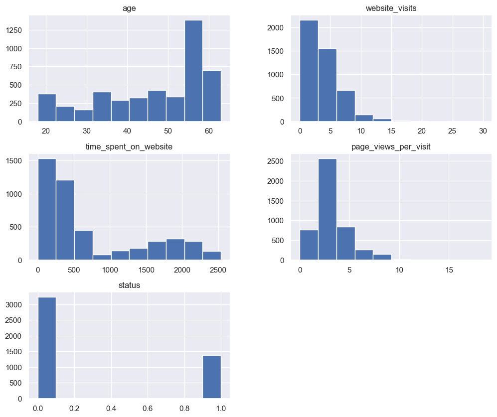

```python
# Creating the histograms
df[num_cols].hist(figsize=(12,10))
plt.show()
```

#### Observations:

We may wish to look at the numerical variables distributions more closely and confirm what we observed in the basic histograms whilst checking other statistical measures e.g., the median and if outliers are present.

```python
# Defining the hist_box() function that plots a boxplot and histogram in one visual.
def hist_box(df, col):
    f, (ax_box, ax_hist) = plt.subplots(2, sharex=True, gridspec_kw={'height_ratios': (0.15, 0.85)}, figsize=(12, 6))
    # Adding a graph in each part
    sns.boxplot(data=df, x=col, ax=ax_box, showmeans=True)
    sns.histplot(data=df, x=col, kde=True, ax=ax_hist)
    plt.show()
```

##### Plotting the histogram and box plot for the variable `age`

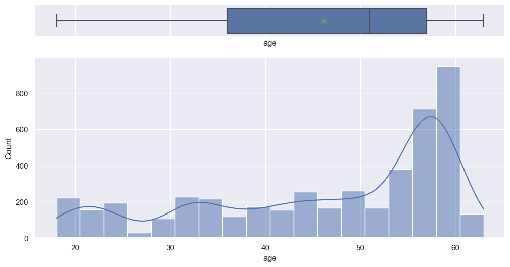

```python
hist_box(df, 'age')
```

** We see that the median age is just over 50 and there are no outliers observed.

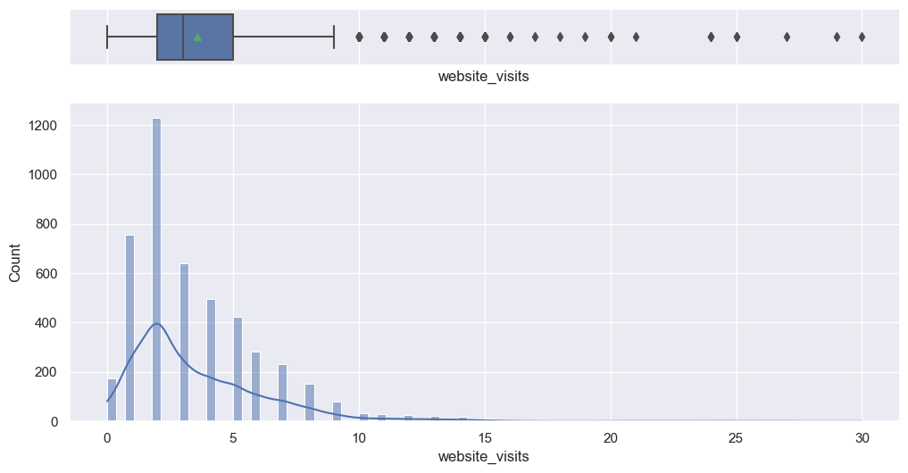

```python
hist_box(df, 'website_visits')
```

** We see that the median number of website visits is approximately 3 - 3.5. Also, there are several outliers observed, even as much as 10 times the median value.

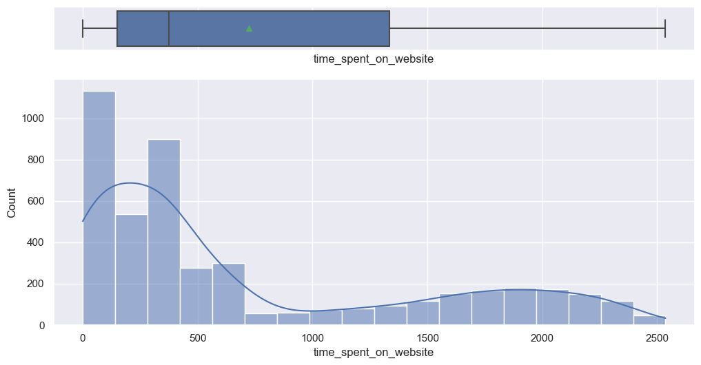

```python
hist_box(df, 'time_spent_on_website')
```

** The median time spent on the website visit approximately 6 - 7 minutes (400/60). There are no outliers observed.

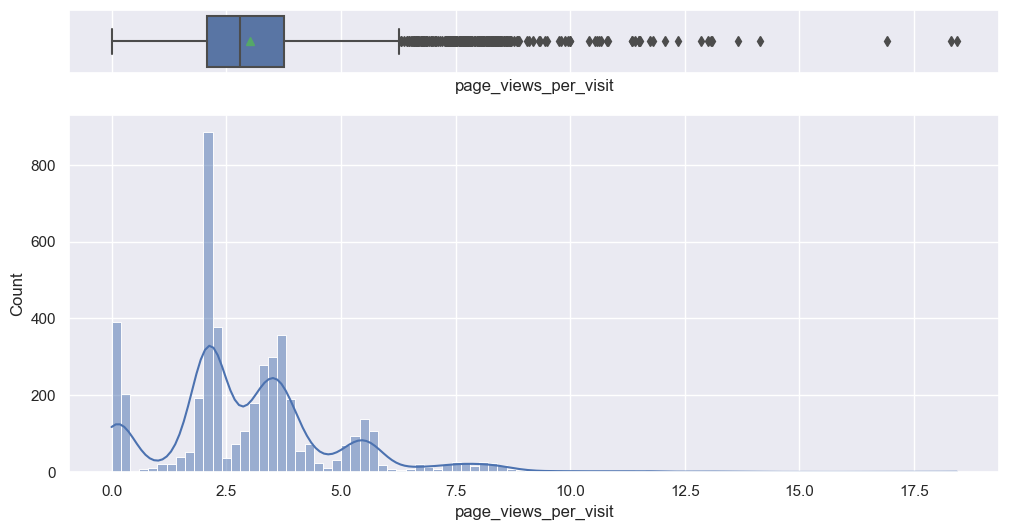

```python
hist_box(df, 'page_views_per_visit')
```

** The median number of page views per visits is approximately 2.7 and close to the mean. There are several outliers observed with some being quite extreme.

```python
# Checking outliers in the column website visits
df[df['website_visits']>10]
```

|  | age | current_occupation | first_interaction | profile_completed | website_visits | time_spent_on_website | page_views_per_visit | last_activity | print_media_type1 | print_media_type2 | digital_media | educational_channels | referral | status |
| --- | --- | --- | --- | --- | --- | --- | --- | --- | --- | --- | --- | --- | --- | --- |
| 6 | 56 | Professional | Mobile App | Medium | 13 | 625 | 2.02 | Website Activity | No | No | Yes | No | No | 1 |
| 31 | 55 | Unemployed | Website | Medium | 13 | 1055 | 1.37 | Email Activity | No | No | Yes | Yes | No | 1 |
| 32 | 58 | Professional | Mobile App | High | 12 | 1151 | 18.43 | Phone Activity | No | No | No | Yes | No | 0 |
| 66 | 59 | Unemployed | Mobile App | Medium | 25 | 311 | 2.18 | Phone Activity | No | No | Yes | No | No | 0 |
| 201 | 57 | Professional | Mobile App | High | 14 | 66 | 2.04 | Email Activity | No | No | No | Yes | No | 0 |
| ... | ... | ... | ... | ... | ... | ... | ... | ... | ... | ... | ... | ... | ... | ... |
| 4566 | 59 | Unemployed | Mobile App | High | 13 | 30 | 3.20 | Website Activity | No | No | No | Yes | No | 0 |
| 4571 | 54 | Professional | Website | High | 12 | 1513 | 5.70 | Email Activity | No | No | No | No | No | 1 |
| 4583 | 49 | Professional | Website | Medium | 24 | 1039 | 2.06 | Email Activity | Yes | No | No | No | No | 1 |
| 4589 | 21 | Student | Website | High | 16 | 251 | 2.11 | Phone Activity | No | No | No | No | No | 0 |
| 4607 | 35 | Unemployed | Mobile App | Medium | 15 | 360 | 2.17 | Phone Activity | No | No | No | Yes | No | 0 |

120 rows × 14 columns

** There are 120 outliers in the website visits column, about 3% of the observations (120/4612).

```python
# Checking outliers in the column page views per visit
df[df['page_views_per_visit']>6]
```

|  | age | current_occupation | first_interaction | profile_completed | website_visits | time_spent_on_website | page_views_per_visit | last_activity | print_media_type1 | print_media_type2 | digital_media | educational_channels | referral | status |
| --- | --- | --- | --- | --- | --- | --- | --- | --- | --- | --- | --- | --- | --- | --- |
| 4 | 23 | Student | Website | High | 4 | 600 | 16.91 | Email Activity | No | No | No | No | No | 0 |
| 32 | 58 | Professional | Mobile App | High | 12 | 1151 | 18.43 | Phone Activity | No | No | No | Yes | No | 0 |
| 47 | 35 | Professional | Mobile App | Medium | 2 | 497 | 7.05 | Email Activity | No | No | No | No | No | 0 |
| 110 | 31 | Professional | Website | High | 1 | 187 | 7.36 | Email Activity | No | No | No | Yes | No | 1 |
| 121 | 56 | Professional | Mobile App | Medium | 2 | 561 | 6.89 | Email Activity | No | No | No | No | No | 0 |
| ... | ... | ... | ... | ... | ... | ... | ... | ... | ... | ... | ... | ... | ... | ... |
| 4481 | 48 | Professional | Mobile App | Medium | 2 | 881 | 6.17 | Email Activity | No | No | No | Yes | No | 0 |
| 4507 | 33 | Professional | Mobile App | High | 5 | 83 | 6.82 | Email Activity | No | No | No | No | No | 0 |
| 4514 | 42 | Professional | Mobile App | Medium | 2 | 762 | 8.00 | Phone Activity | No | No | No | No | No | 0 |
| 4572 | 55 | Unemployed | Mobile App | High | 1 | 617 | 7.40 | Phone Activity | No | No | No | No | No | 0 |
| 4597 | 20 | Student | Website | Medium | 2 | 364 | 8.25 | Email Activity | No | No | No | Yes | No | 0 |

268 rows × 14 columns

** There are 268 outliers in the page views per visit column, about 6% of the observations (268/4612).

#### Observations:

The percentages of outliers in the respective columns are not significant enough to cause bias or distortion in the statistical measurements. I will therefore keep them in the dataset and proceed with further analysis.

#### Univariate anaysis - Categorical data

```python
# Setting the figure size for plots generated with seaborn
import seaborn as sns
sns.set(rc={"figure.figsize": (10,4)})  # width = 8, height = 6
sns.set_palette("tab10")
```

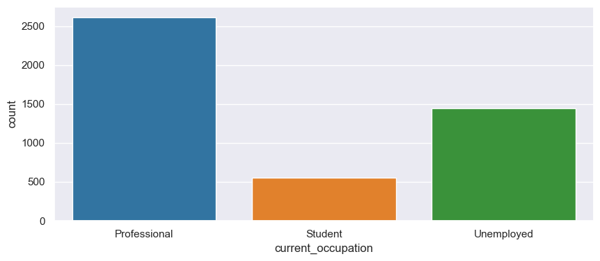

```python
# Current occupation
sns.countplot(x = df['current_occupation'])
plt.show()
```

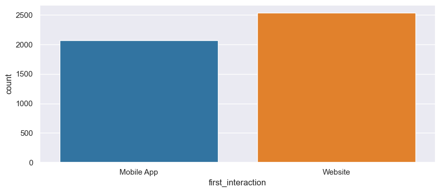

```python
# First interaction
sns.countplot(x = df['first_interaction'])
plt.show()
```

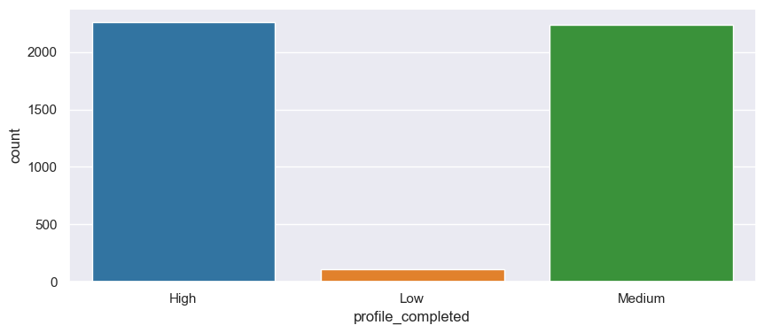

```python
# Profile completed
sns.countplot(x = df['profile_completed'])
plt.show()
```

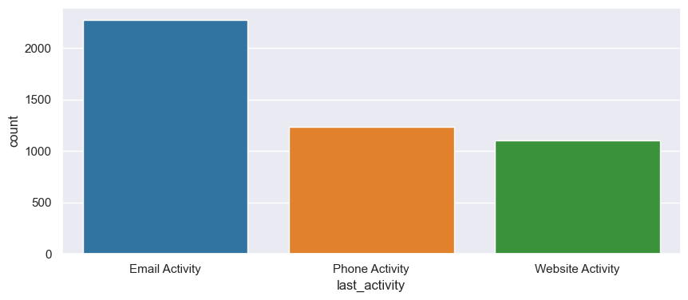

```python
# Last activity
sns.countplot(x = df['last_activity'])
plt.show()
```

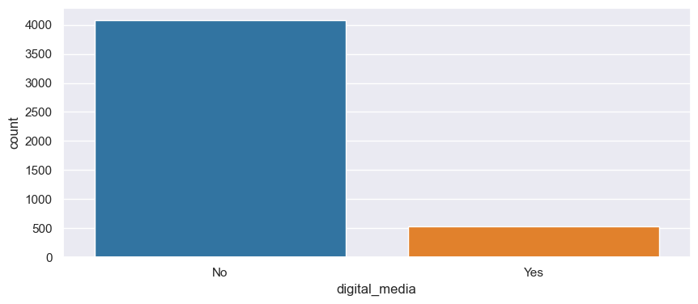

```python
# Digital media
sns.countplot(x = df['digital_media'])
plt.show()
```

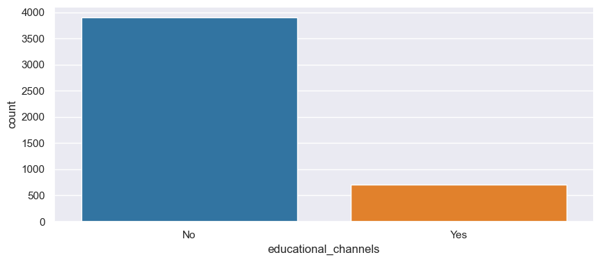

```python
# Educational channels
sns.countplot(x = df['educational_channels'])
plt.show()
```

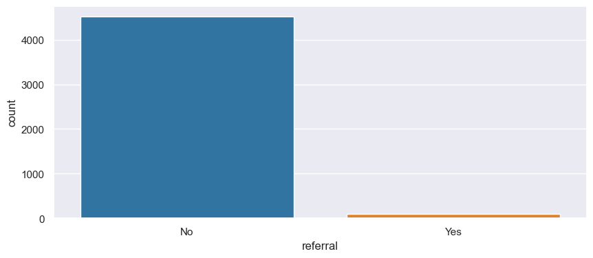

```python
# Referral
sns.countplot(x = df['referral'])
plt.show()
```

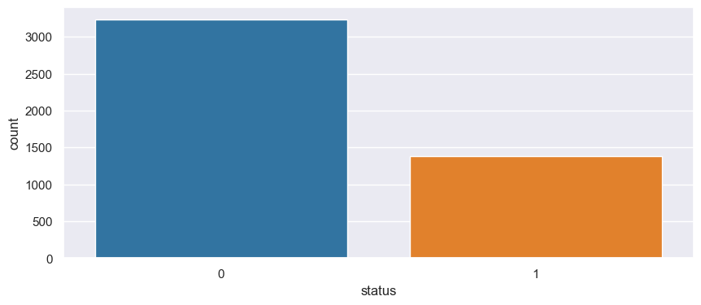

```python
# Status
sns.countplot(x = df['status'])
plt.show()
```

** In addition to the plots, it would be useful to see the breakdown of the categorical variables in more granular detail and note down the observations.

```python
# Making a list of all categorical variables
cat_cols=['current_occupation', 'first_interaction','profile_completed', 'last_activity',
         'print_media_type1','print_media_type2','digital_media', 'educational_channels', 'referral']

# Printing number of count of each unique value in each column
for column in cat_col:
    print(df[column].value_counts()) # function for counts by sub-category
    print(df[column].value_counts(normalize=True)) # normalizing the results
    print('-'*30)
```

```
current_occupation
Professional    2616
Unemployed      1441
Student          555
Name: count, dtype: int64
current_occupation
Professional   0.57
Unemployed     0.31
Student        0.12
Name: proportion, dtype: float64
------------------------------
first_interaction
Website       2542
Mobile App    2070
Name: count, dtype: int64
first_interaction
Website      0.55
Mobile App   0.45
Name: proportion, dtype: float64
------------------------------
profile_completed
High      2264
Medium    2241
Low        107
Name: count, dtype: int64
profile_completed
High     0.49
Medium   0.49
Low      0.02
Name: proportion, dtype: float64
------------------------------
last_activity
Email Activity      2278
Phone Activity      1234
Website Activity    1100
Name: count, dtype: int64
last_activity
Email Activity     0.49
Phone Activity     0.27
Website Activity   0.24
```

[output cut: 32 more lines]

```
Name: count, dtype: int64
educational_channels
No    0.85
Yes   0.15
Name: proportion, dtype: float64
------------------------------
referral
No     4519
Yes      93
Name: count, dtype: int64
referral
No    0.98
Yes   0.02
Name: proportion, dtype: float64
------------------------------
```

#### Observations:

The summary of the categorical variables shows:

- **Professionals account for around 60%** of the leads, followed by **unemployed 30%** and **students 10%**.
- The **first interaction** by leads with the company are on the **website 55%**, followed by **mobile 45%**.
- The leads have a **High - 49%** to **Medium - 48%** profile completion rate.
- **Email activity** accounted for the about **50% of last activity** .
- The **majority of the leads indicated not having seen the advert** for Extraalearn in **both print media types**, **~89% newspaper** and **~95% magazine**.
- Interestingly, majority of the leads also indicated not having seen the ad on; digital platforms **~88%** and educational channels **~85%**.
- Around **2% of the leads were by referral**.

### Bivariate and Multivariate analysis

Next I wantstow check howthe observations of status, our target variable, are relatedtohthe predictor variables Given that the values in the status column are a flag indicating whether the lead was converted to a paid customer or not, we can assume that status 0 = lead not converted and 1 = lead converted. This thinking aligns with the concept of a sales/marketing conversion funnel whereby leads that eventually become paid customers tend to be less than those targeted through marketing efforts. .

I will define a plot function to visualise the relationships percentage-wise using stacked bar plots.

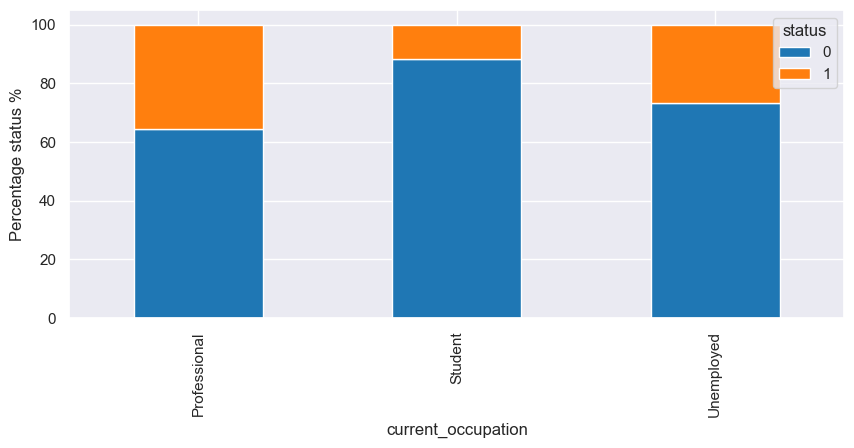

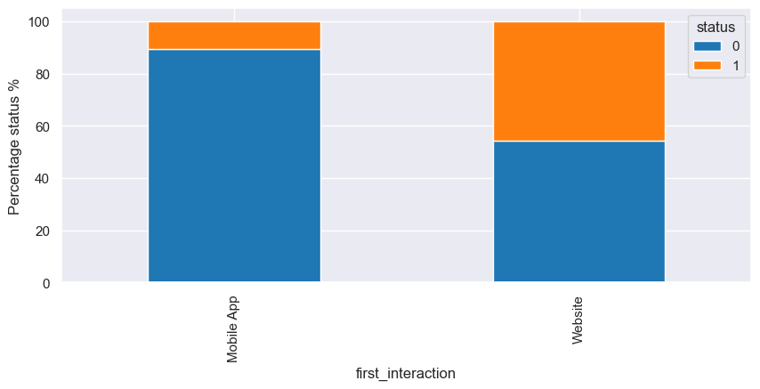

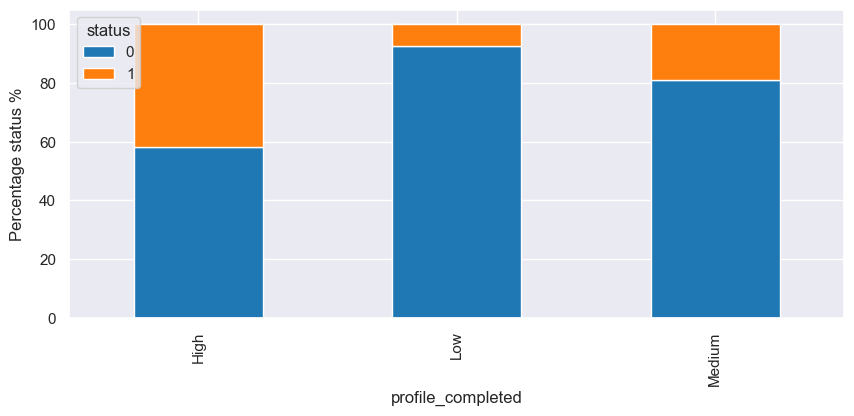

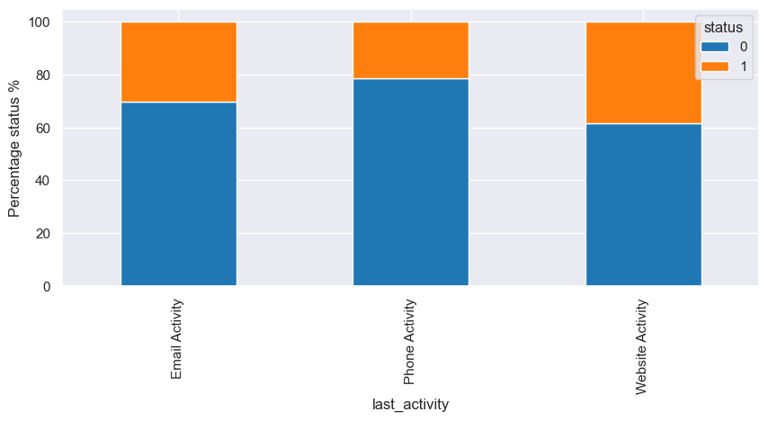

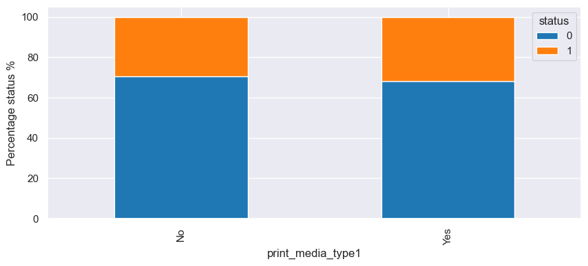

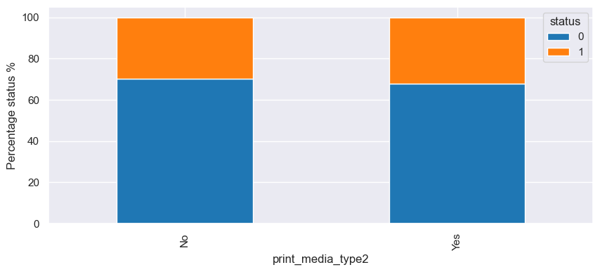

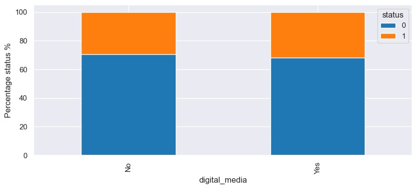

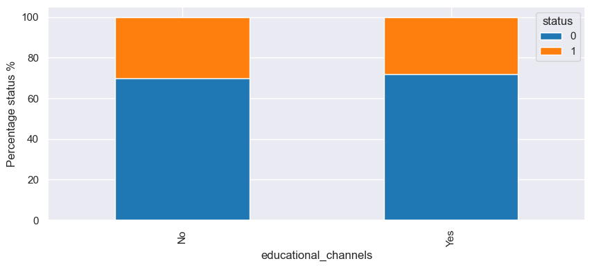

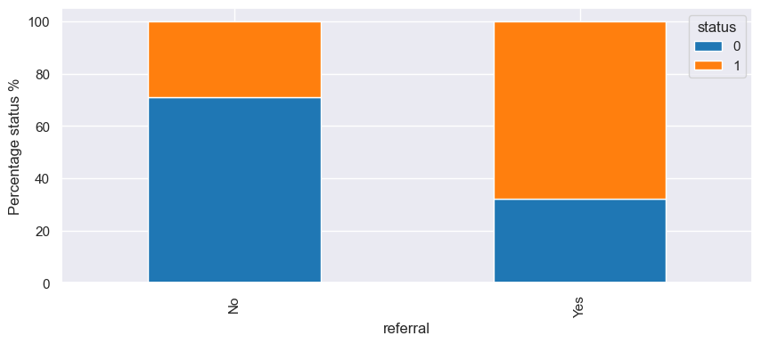

```python
# Let us plot  for the variables.
for i in cat_cols:
    if i!='status':
        (pd.crosstab(df[i],df['status'],normalize='index')*100).plot(kind='bar',figsize=(10,4),stacked=True)
        plt.ylabel('Percentage status %')
```

#### Observations:

**Checking the relationship between conversion i.e., status and the numerical variables**

```python
# Mean of numerical variables grouped by status
df.groupby(['status'])[num_cols].mean()
```

| status | age | website_visits | time_spent_on_website | page_views_per_visit | status |
| --- | --- | --- | --- | --- | --- |
| 0 | 45.15 | 3.58 | 577.42 | 3.03 | 0.00 |
| 1 | 48.66 | 3.54 | 1068.40 | 3.03 | 1.00 |

**Observations:**

- **Leads converting** to paying customers were of **average age 49**.
- The number of **website visits was not a strong indicator of likelihood to convert**, as the time spent by conversions was approximate to that of non-conversions.
- The conversions' **time spent on website** was nearly twice that spent by non-conversions i.e, around 18 and 10 minutes, respectively.
- Similarly to website visits **page views per visit** was also not a strong indicator of likelihood to convert as both conversions and non-conversions viewed an average of around 3 pages during website visits.

**From the observations above, we have arrived at a profile of the type of leads that tend to become converted to paying customers.**

### **Checking the relationship between different numerical variables**

#### Heat map

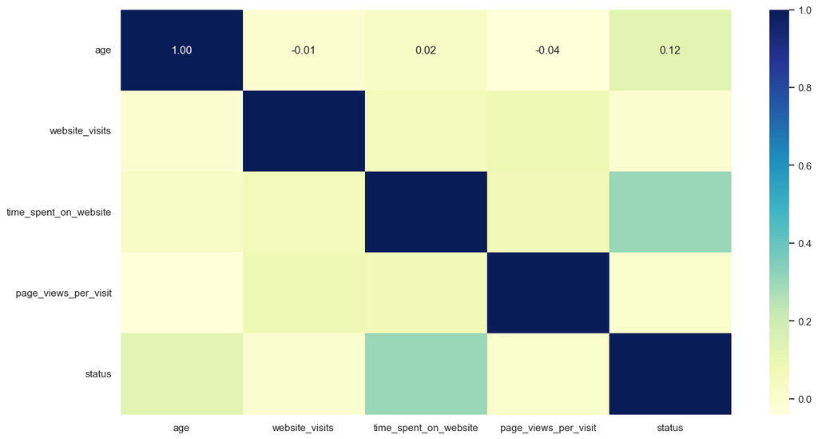

```python
# Finding and visualising the correlation between the numerical variables using a heatmap
# Plotting the correlation between numerical variables
plt.figure(figsize=(15,8))
sns.heatmap(df[num_cols].corr(),annot=True, fmt='0.2f', cmap='YlGnBu');
```

## **Model Building - Approach**

1. Data preparation.
2. Partition the data into a train and test set.
3. Build a model on the train data.
4. Tune the model if required.
5. Test the data on the test set.

### **Data Preparation**

**Since there are several categorical observations which contain strings, I wish to create dummy variables in order to continue with modelling.**

```python
# Creating list of dummy columns
to_get_dummies_for = ['current_occupation', 'first_interaction','profile_completed',
                      'last_activity','print_media_type1','print_media_type2','digital_media',
                      'educational_channels', 'referral']

# Creating dummy variables
df_new = pd.get_dummies(data = df, columns = to_get_dummies_for, drop_first = True)
df_new_copy = df_new.copy()
df_new.head()
```

|  | age | website_visits | time_spent_on_website | page_views_per_visit | status | current_occupation_Student | current_occupation_Unemployed | first_interaction_Website | profile_completed_Low | profile_completed_Medium | last_activity_Phone Activity | last_activity_Website Activity | print_media_type1_Yes | print_media_type2_Yes | digital_media_Yes | educational_channels_Yes | referral_Yes |
| --- | --- | --- | --- | --- | --- | --- | --- | --- | --- | --- | --- | --- | --- | --- | --- | --- | --- |
| 0 | 57 | 7 | 1639 | 1.86 | 1 | False | True | True | False | False | False | True | True | False | True | False | False |
| 1 | 56 | 2 | 83 | 0.32 | 0 | False | False | False | False | True | False | True | False | False | False | True | False |
| 2 | 52 | 3 | 330 | 0.07 | 0 | False | False | True | False | True | False | True | False | False | True | False | False |
| 3 | 53 | 4 | 464 | 2.06 | 1 | False | True | True | False | False | False | True | False | False | False | False | False |
| 4 | 23 | 4 | 600 | 16.91 | 0 | True | False | True | False | False | False | False | False | False | False | False | False |

```python
# Modifying the column names for the dummy variables created from the column 'last activity'
df_new = df_new.rename(columns={'last_activity_Phone Activity':'last_activity_Phone',
                                'last_activity_Website Activity':'last_activity_Website',
                                'print_media_type1_Yes':'print_media_type_Newspaper',
                                'print_media_type2_Yes':'print_media_type_Magazine'})
```

```python
df_new.isnull().sum()
```

```
age                              0
website_visits                   0
time_spent_on_website            0
page_views_per_visit             0
status                           0
current_occupation_Student       0
current_occupation_Unemployed    0
first_interaction_Website        0
profile_completed_Low            0
profile_completed_Medium         0
last_activity_Phone              0
last_activity_Website            0
print_media_type_Newspaper       0
print_media_type_Magazine        0
digital_media_Yes                0
educational_channels_Yes         0
referral_Yes                     0
dtype: int64
```

**Defining the predictor variables (X) and the target variable (Y)**

```python
# Separating the dependent variable and other variables
X=df_new.drop(columns='status')
Y=df_new['status']
```

**Splitting the data into a 70% train and 30% test set**

I will use the stratified sampling technique to ensure that relative class frequencies are approximately preserved in each train and validation fold.

```python
# Splitting the data into train and test sets
X_train,X_test,y_train,y_test=train_test_split(X,Y,test_size=0.30,random_state=1,stratify=Y)
```

### **Scaling the data**

I will conduct **Feature Scaling**, i.e. scaling the dataset so as to give every transformed variable a comparable scale when running the **Logistic Regression** and **SVM**. The tree-based models **Decision Tree** and **Random Forest** are not sensitive to the magnitude of variables, thus there is no need to standardise or normalise the data before fitting the tree-based models.

```python
# Standardizing the data using the **Standard Scaler** method.
# It centers and scales the dataset using the Z-Score.
```

```python
# importing from SciKit learn
from sklearn.preprocessing import StandardScaler

# Scaling the data
sc = StandardScaler()

# Fit_transform on train data
X_train_scaled=sc.fit_transform(X_train)
X_train_scaled=pd.DataFrame(X_train_scaled, columns=X.columns)

# Transform on test data
X_test_scaled=sc.transform(X_test)
X_test_scaled=pd.DataFrame(X_test_scaled, columns=X.columns)
```

```python
# Creating metric function
def metrics_score(actual, predicted):
    print(classification_report(actual, predicted))

    cm = confusion_matrix(actual, predicted)
    plt.figure(figsize=(8,5))

    sns.heatmap(cm, annot=True,  fmt='.2f')
    plt.ylabel('Actual')
    plt.xlabel('Predicted')
    plt.show()
```

## **Model evaluation criterion:**

#### **The model can make wrong predictions which may lead to loss of resources or opportunity e.g.:**

1. Predicting a conversion by a lead which does not happen
2. Predicting a lead will not convert into a paying customer whereas the lead does convert

#### **Which case is more important?**

- Given the business problem our models should ideally predict that customer will be converted given e.g., the resources such as marketing expenditure on several platforms by the company. Thus, higher efforts can be focused on targeting true positives which represent a potential source of income for the company and by implication a return on marketing spend.

#### **How to increase this conversions i.e., improve True Positives?**

- Since we are dealing with imbalanced classes in our dataset, increasing true positives would require a strategy such as maximizing Recall, the greater the Recall, the lesser the chances of false negatives. Experimenting with different approaches therefore allows us to find the best balance between true positives and false positives.

## Building the model

We will be building 4 different models and compare the results against one another in order to ensure the best performing model is used in the final analysis as well as making recommendations to the company.

- **Logistic Regression**
- **Support Vector Machine(SVM)**
- **Decision Tree**
- **Random Forest**

### **Logistic Regression**

```python
# Fitting logistic regression model
lg=LogisticRegression()
lg.fit(X_train_scaled,y_train)
```

```
LogisticRegression()
```

#### Checking the performance of the model on train and test data

```
              precision    recall  f1-score   support

           0       0.85      0.90      0.88      2264
           1       0.73      0.64      0.68       964

    accuracy                           0.82      3228
   macro avg       0.79      0.77      0.78      3228
weighted avg       0.82      0.82      0.82      3228
```

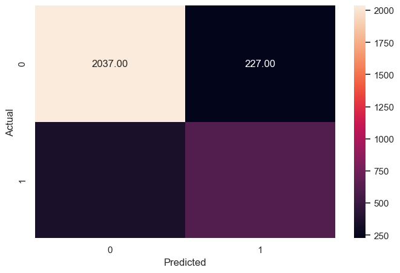

```python
# Checking the performance on the training data
y_pred_train = lg.predict(X_train_scaled)

metrics_score(y_train, y_pred_train)
```

#### Observations:

- The reported average includes the macro average which averages the unweighted mean per label, and the weighted average i.e., averaging the support-weighted mean per label.
- In classification, the class of interest is considered the positive class. Here, the class of interest is 1 which identifies the leads that convert into paying customers.

**Reading the confusion matrix (clockwise):**

- True Negative (Actual=0, Predicted=0): Model predicts that a lead would not convert and the lead does not convert
- False Positive (Actual=0, Predicted=1): Model predicts that a lead would conver but the lead does not convert
- False Negative (Actual=1, Predicted=0): Model predicts that a lead would not convert but the lead converts
- True Positive (Actual=1, Predicted=1): Model predicts that a lead would convert and the lead actually converts

```
              precision    recall  f1-score   support

           0       0.85      0.91      0.88       971
           1       0.75      0.63      0.69       413

    accuracy                           0.83      1384
   macro avg       0.80      0.77      0.78      1384
weighted avg       0.82      0.83      0.82      1384
```

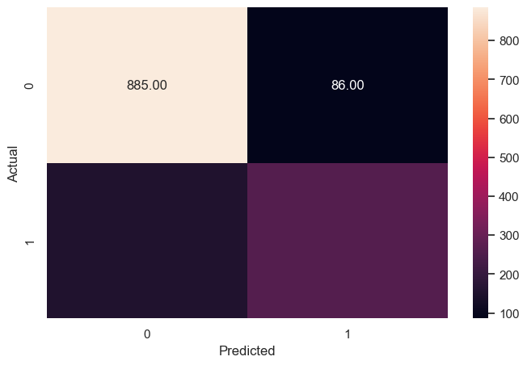

```python
# Checking the performance on the test dataset
y_pred_test = lg.predict(X_test_scaled)

metrics_score(y_test, y_pred_test)
```

```python
# Creating objects out of the results to allow for summarisation
train_accuracy = 0.82
train_precision_01 = 0.73
train_recall_01 = 0.64
train_f1_01 = 0.68
train_support_01 = 964

test_accuracy =  0.83
test_precision_01 = 0.75
test_recall_01 = 0.63
test_f1_01 = 0.69
test_support_01 = 413
```

#### Observations:

- **We get an accuracy of ~82.5%** on train and test dataset.
- However, **the recall for this model is only ~64% for class 1 on train and 63% on test.**
- The recall is good, but it **will not perform well** in differentiating out those leads who have a high probability of converting.

### Checking the coefficients to find which variables are leading to conversion and can improve it.

```python
# Displaying the coefficients of logistic regression
cols=X.columns

coef_lg=lg.coef_

pd.DataFrame(coef_lg,columns=cols).T.sort_values(by = 0,ascending = False)
```

|  | 0 |
| --- | --- |
| first_interaction_Website | 1.30 |
| time_spent_on_website | 0.86 |
| last_activity_Website | 0.25 |
| referral_Yes | 0.20 |
| age | 0.08 |
| educational_channels_Yes | 0.04 |
| print_media_type_Magazine | 0.03 |
| digital_media_Yes | 0.03 |
| print_media_type_Newspaper | 0.02 |
| page_views_per_visit | -0.04 |
| website_visits | -0.07 |
| current_occupation_Unemployed | -0.28 |
| last_activity_Phone | -0.33 |
| profile_completed_Low | -0.40 |
| current_occupation_Student | -0.58 |
| profile_completed_Medium | -0.81 |

#### Observations:

The **features that have a positive effect** on the conversion rate are:

- **First_interaction_Website**, the most important feature in determining if a lead will convert or not
- **Time_spent_on_website**, the second most important feature indicating sucessful conversions
- **Last_activity_Website**, the third most significant feature which supports the importance of website interaction as being a key indicator of probability to convert into a paying customer
- **Referral_Yes**, the fourth most important feature shows that personal referral of leads to the company is also a key indicator of probability to convert

The *remaining features with positive effect on conversion but with less strength than top four are:

- Educational_channels_Yes
- Print_media_type_Magazine
- Digital_media_Yes
- Print_media_type_Newspaper

The **features that have a negative effect** on the conversion rate are:

- **Profile_completed_Medium**, there is an inverse relationship between conversion and profiles with medium completion such that the feature can be seen as a flag that a lead is not likely to convert
- **Current_occupation_Student**, when leads identify themselves as students, they are likely not to convert
- **Profile_completed_Low**, low profile completion rate is another flag for the likelihood of a lead not to conver
- **Last_activity_Phone**, when the last activity of the lead was telephonic engagement, the indication is that they are likely not to convert
- **Current_occupation_Unemployed**, the model captures that when leads identifying themselves as unemployed are not likely to convert

The remaining features with negative effect on conversion but with less strength are:

- Website_visits, is also slightly negatively correlated with conversion
- Page_views_per_visit, is slightly negatively correlated with conversion which indicates that the number of pages viewed per visit is not a good indicator of likelihood to convert into a paying customer

```python
# Finding the odds
odds = np.exp(lg.coef_[0])

# Adding the odds to a dataframe and sorting the values
pd.DataFrame(odds, X_train_scaled.columns, columns = ['odds']).sort_values(by ='odds', ascending = False)
```

|  | odds |
| --- | --- |
| first_interaction_Website | 3.67 |
| time_spent_on_website | 2.37 |
| last_activity_Website | 1.28 |
| referral_Yes | 1.22 |
| age | 1.08 |
| educational_channels_Yes | 1.04 |
| print_media_type_Magazine | 1.03 |
| digital_media_Yes | 1.03 |
| print_media_type_Newspaper | 1.03 |
| page_views_per_visit | 0.96 |
| website_visits | 0.94 |
| current_occupation_Unemployed | 0.76 |
| last_activity_Phone | 0.72 |
| profile_completed_Low | 0.67 |
| current_occupation_Student | 0.56 |
| profile_completed_Medium | 0.45 |

#### Observations:

Having converted the log odds into real odds, we can interpret the results as follows:

- The odds of a lead who had their first intercation on the website converting are 3.7 times the odds of one who did not.
- The odds of a lead who spent a certain amount of time on the website (e.g., the average time spent by leads) converting are 2.4 times the odds of one who did spent the at least that much time.
- The odds of a lead whose last activity was whilst visiting the website converting are 1.3 times the odds of with another last activity.

#### **Finding the optimal threshold for the model using the Precision-Recall Curve**

Precision-Recall curve summarizes the trade-off between the true positive rate and the positive predictive value for a predictive model using different probability thresholds. Thus using the Precision-Recall curve, we can attempt to find a **better threshold.**

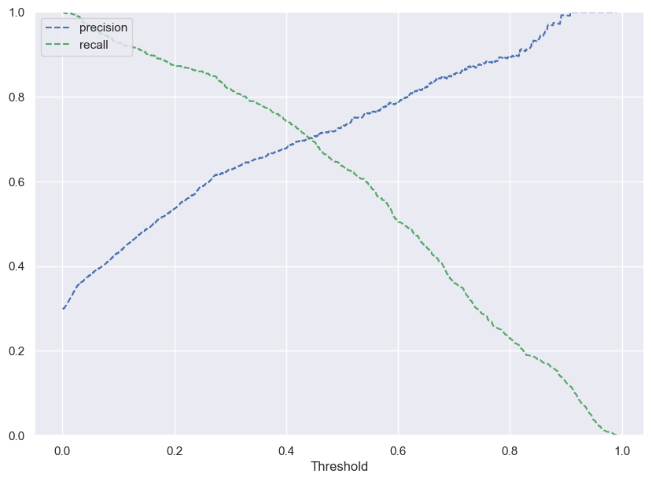

```python
# Predict_proba gives the probability of each observation belonging to each class
y_scores_lg=lg.predict_proba(X_train_scaled)

precisions_lg, recalls_lg, thresholds_lg = precision_recall_curve(y_train, y_scores_lg[:,1])

# Plot values of precisions, recalls, and thresholds
plt.figure(figsize=(10,7))
plt.plot(thresholds_lg, precisions_lg[:-1], 'b--', label='precision')
plt.plot(thresholds_lg, recalls_lg[:-1], 'g--', label = 'recall')
plt.xlabel('Threshold')
plt.legend(loc='upper left')
plt.ylim([0,1])
plt.show()
```

#### Observations:

- We can see that precision and recall are balanced for a threshold of about ~**0.45**.

```
              precision    recall  f1-score   support

           0       0.87      0.88      0.87      2264
           1       0.71      0.69      0.70       964

    accuracy                           0.82      3228
   macro avg       0.79      0.79      0.79      3228
weighted avg       0.82      0.82      0.82      3228
```

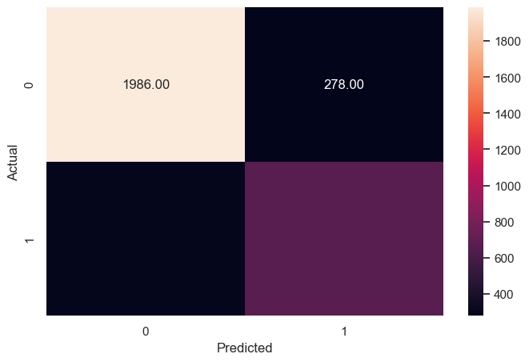

```python
# Checking the performance of the model at this threshold**
optimal_threshold=.45
y_pred_train = lg.predict_proba(X_train_scaled)

metrics_score(y_train, y_pred_train[:,1]>optimal_threshold)
```

```
              precision    recall  f1-score   support

           0       0.87      0.89      0.88       971
           1       0.72      0.68      0.70       413

    accuracy                           0.83      1384
   macro avg       0.80      0.79      0.79      1384
weighted avg       0.82      0.83      0.83      1384
```

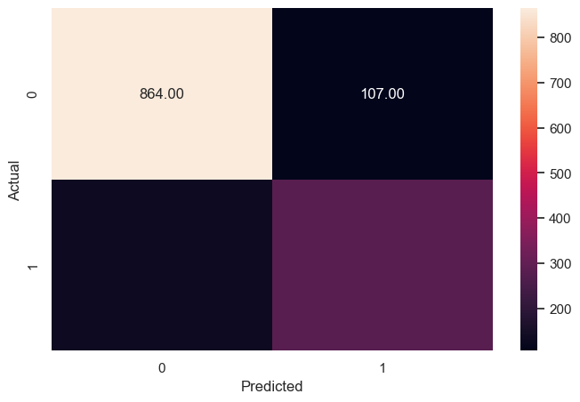

```python
optimal_threshold=.45
y_pred_test = lg.predict_proba(X_test_scaled)

metrics_score(y_test, y_pred_test[:,1]>optimal_threshold)
```

```python
# Creating objects out of the results, after setting the optimal threshold, to allow for summarisation
train_accuracy_ot = 0.82
train_precision_01_ot = 0.71
train_recall_01_ot = 0.69
train_f1_01_ot = 0.70
train_support_01_ot = 964

test_accuracy_ot =  0.83
test_precision_01_ot = 0.72
test_recall_01_ot = 0.68
test_f1_01_ot = 0.70
test_support_01_ot = 413
```

```python
# Creating a summary table of the performance on test for status = 1
summary_lr = pd.DataFrame({
    'Metric ': ['Accuracy', 'Precision', 'Recall', 'F1-score', 'Support'],
    'Train': [train_accuracy, train_precision_01, train_recall_01, train_f1_01, train_support_01],
    'Test': [test_accuracy, test_precision_01, test_recall_01, test_f1_01, test_support_01]
})
summary_lr_ot = pd.DataFrame({
    'OT Metric': ['Accuracy', 'Precision', 'Recall', 'F1-score', 'Support'],
 'Train': [train_accuracy_ot, train_precision_01_ot, train_recall_01_ot, train_f1_01_ot, train_support_01_ot],
    'Test': [test_accuracy_ot, test_precision_01_ot, test_recall_01_ot, test_f1_01_ot, test_support_01_ot]
})
```

```python
# Viewing the summary tables side-by-side using pd.concatenate() function
lr_result = pd.concat([summary_lr, summary_lr_ot], axis=1)
lr_result.drop(index=4, inplace=True)
lr_result
```

|  | Metric | Train | Test | OT Metric | Train | Test |
| --- | --- | --- | --- | --- | --- | --- |
| 0 | Accuracy | 0.82 | 0.83 | Accuracy | 0.82 | 0.83 |
| 1 | Precision | 0.73 | 0.75 | Precision | 0.71 | 0.72 |
| 2 | Recall | 0.64 | 0.63 | Recall | 0.69 | 0.68 |
| 3 | F1-score | 0.68 | 0.69 | F1-score | 0.70 | 0.70 |

#### Observations:

- The model is giving similar performance on the test and train data.
- After setting optimal threshold to 0.45, the recall of the test data has not increased significantly, whilst the precision has decreased slightly. This is suprising as we expect an improvement after adjusting the threshold.
- We also see that the average recall and precision for the model are good however we are interested in finding the best performance, therefore we must try other algorithms.

### **Support Vector Machine (SVM)**

In order to achieve optimal performance in the SVM algorithm and accelerate training, we need to scale the data.

The benefits of scaling include:

- improved performance because all features are treated equally
- convergence during optimization
- ensuring consistent behavior across different kernel functions

```python
# Scaling the data using the MinMaxScaler() function
scaling = MinMaxScaler(feature_range=(-1,1)).fit(X_train)
X_train_scaled = scaling.transform(X_train)
X_test_scaled = scaling.transform(X_test)
```

I will build SVM models using the two of the widely used kernel functions:

1. **Linear Kernel**
2. **RBF Kernel**

#### **Linear Kernel**

##### Building the Support Vector Machine model using a linear kernel

```python
# Fitting SVM
svm = SVC(kernel='linear') # Linear kernal or linear decision boundary
model = svm.fit(X= X_train_scaled, y = y_train)
```

Checking the performance of the model on train and test data

```
              precision    recall  f1-score   support

           0       0.87      0.89      0.88      2264
           1       0.72      0.68      0.70       964

    accuracy                           0.82      3228
   macro avg       0.79      0.78      0.79      3228
weighted avg       0.82      0.82      0.82      3228
```

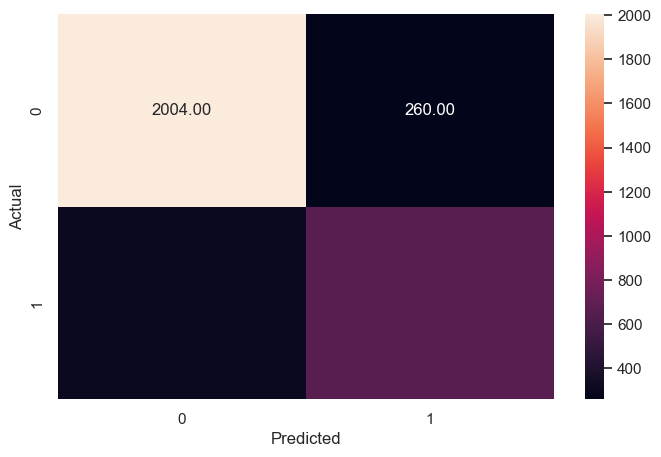

```python
# Checking performance on the train data set
y_pred_train_svm = model.predict(X_train_scaled)

metrics_score(y_train, y_pred_train_svm)
```

```
              precision    recall  f1-score   support

           0       0.87      0.89      0.88       971
           1       0.73      0.68      0.70       413

    accuracy                           0.83      1384
   macro avg       0.80      0.79      0.79      1384
weighted avg       0.83      0.83      0.83      1384
```

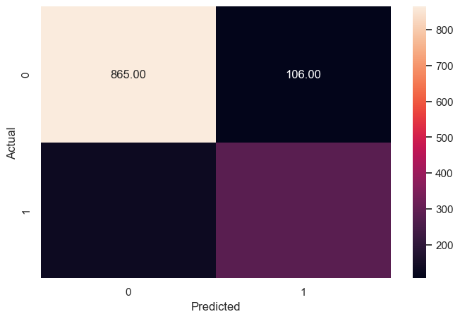

```python
# Checking performance on the test data set
y_pred_test_svm = model.predict(X_test_scaled)

metrics_score(y_test, y_pred_test_svm)
```

```python
# Creating objects out of the results to allow for summarisation
SVM_train_accuracy = 0.82
SVM_train_precision_01 = 0.72
SVM_train_recall_01 = 0.68
SVM_train_f1_01 = 0.70
SVM_train_support_01 = 964

SVM_test_accuracy =  0.83
SVM_test_precision_01 = 0.73
SVM_test_recall_01 = 0.68
SVM_test_f1_01 = 0.70
SVM_test_support_01 = 413
```

#### Observations:

- SVM model with **linear kernel** is not overfitting as the accuracy is ~82,% for both train and test dataset
- The **Recall** for the model is ~68% implying that our model will not predict very well the leads who are likely to convert